# Surveys, Conjoint, and Multilevel Models

IS 5150/6110

# Surveys

## An essential data collection method

*Advantages*

- Easy to administer to a large number of respondents
- Standardized questions provide a basis for comparison
- Structured data simplifies analysis
- Straightforward for respondents

*Disadvantages*

- Getting the right sample can be difficult and expensive
- Stuctured questions may unduly constrain respondents
- Sensitive questions can be challenging to answer
- Proper wording can be difficult

## What makes a good survey?

- Language and phrasing needs to fit the audience
- Wording and structure should encourage completion
- Make it easy to check any display or skip patterns
- Language should be brief, clear, and conversational
- Questions need to be answerable by the audience
- Be careful about assumed knowledge and being ambiguous
- Avoid double-barreled and leading/loaded questions

## Survey tips

- Use projection for potentially loaded questions
- Make rating scales simple and anchored
- Use display and skip patterns to funnel respondents to relevant questions
- Include “Don’t know” or “None of the above” options
- Include an “Other, please specify” open-ended option when you may not have exhaustive response categories
- Consider randomizing question options to minimize order bias
- Consider when to use forced choice

## All measurements come with error

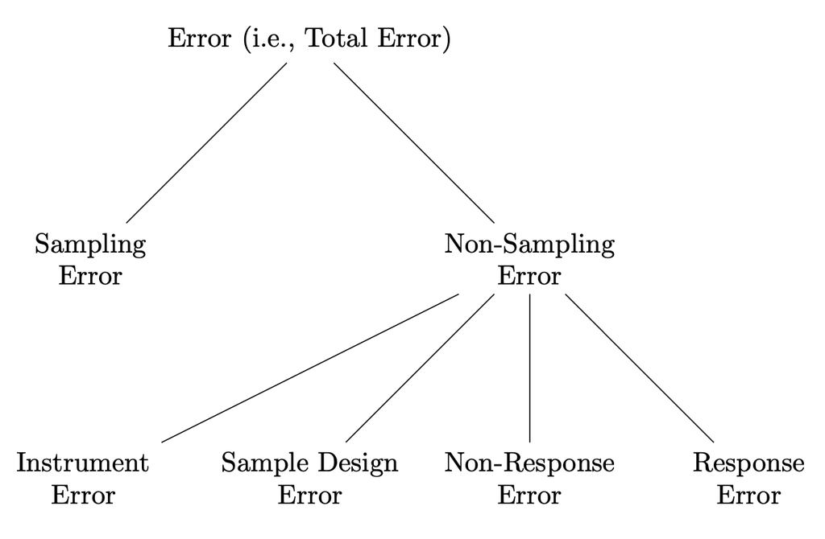

## Ask easy questions first, difficult questions last

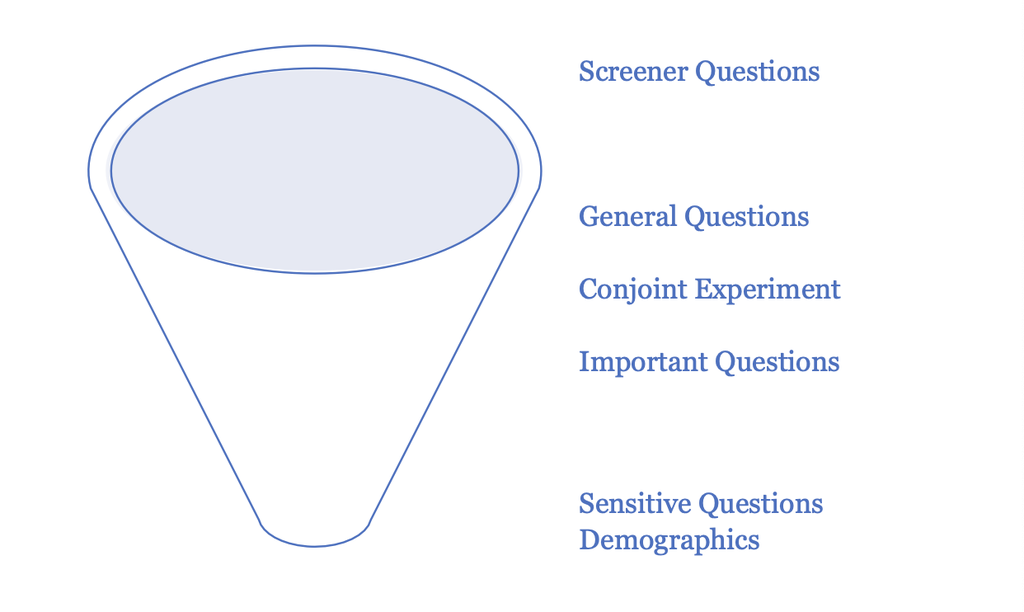

# Conjoint

- Products are defined by attributes, each with a number of levels
- Respondents choose from among product alternatives
- **Respondent-level preferences** are estimated for each attribute level
- Preference estimates are used to make counterfactual predictions in a simulated market
- **Market simulators** inform new product development, pricing, product line optimization, etc.

$$U_{hj} = \beta_{h1}x_{j1} + \beta_{h2}x_{j2} + \cdots + \beta_{hk}x_{jk} + \epsilon_{hj}$$

$$\color{grey}{U_{hj} = \color{black}{\beta_{h1}}x_{j1} + \color{black}{\beta_{h2}}x_{j2} + \cdots + \color{black}{\beta_{hk}}x_{jk} + \epsilon_{hj}}$$

$$\color{grey}{U_{hj} = \beta_{h1}\color{black}{x_{j1}} + \beta_{h2}\color{black}{x_{j2}} + \cdots + \beta_{hk}\color{black}{x_{jk}} + \epsilon_{hj}}$$

## Discrete Choice

For each respondent $h$ and choice task $t$ with $j$ alternatives and $k$ attribute levels:

$$\begin{aligned}
y_{ht} & = \text{argmax}(pr(y_{ht})), \ \text{s.t.} \ y_{ht} \in \left\{1, 2, \cdots, J \right\} \\[2mm]
p(y_{htj}) & = {\exp\left(\beta_{h1}x_{tj1} + \beta_{h2}x_{tj2} + \cdots + \beta_{hk}x_{tjk} \right) \over \sum_{j=1}^J \exp\left(\beta_{h1}x_{tj1} + \beta_{h2}x_{tj2} + \cdots + \beta_{hk}x_{tjk} \right)} \\[2mm]
\color{grey}{B} & \hspace{3mm} \color{grey}{\sim MVN\left(\gamma, \Sigma \right)} \\[2mm]
\color{grey}{\gamma} & \hspace{3mm} \color{grey}{\sim \textit{Normal}(0, 1)} \\[2mm]
\color{grey}{\Sigma} & \hspace{3mm} \color{grey}{= \text{diag}(\tau) \ \Omega \ \text{diag}(\tau)} \\[2mm]
\color{grey}{\Omega} & \hspace{3mm} \color{grey}{\sim LKJ(1)} \\[2mm]
\color{grey}{\tau} & \hspace{3mm} \color{grey}{\sim \textit{Half-Normal}(1, 2)}
\end{aligned}$$

## Discrete Choice

For each respondent $h$ and choice task $t$ with $j$ alternatives and $k$ attribute levels:

$$\begin{aligned}
\color{grey}{y_{ht}} & \hspace{3mm} \color{grey}{= \text{argmax}(pr(y_{ht})), \ \text{s.t.} \ y_{ht} \in \left\{1, 2, \cdots, J \right\}} \\[2mm]
\color{grey}{p(y_{htj})} & \hspace{3mm} \color{grey}{= {\exp\left(\beta_{h1}x_{tj1} + \beta_{h2}x_{tj2} + \cdots + \beta_{hk}x_{tjk} \right) \over \sum_{j=1}^J \exp\left(\beta_{h1}x_{tj1} + \beta_{h2}x_{tj2} + \cdots + \beta_{hk}x_{tjk} \right)}} \\[2mm]
B & \sim MVN\left(\gamma, \Sigma \right) \\[2mm]
\color{grey}{\gamma} & \hspace{3mm} \color{grey}{\sim \textit{Normal}(0, 1)} \\[2mm]
\color{grey}{\Sigma} & \hspace{3mm} \color{grey}{= \text{diag}(\tau) \ \Omega \ \text{diag}(\tau)} \\[2mm]
\color{grey}{\Omega} & \hspace{3mm} \color{grey}{\sim LKJ(1)} \\[2mm]
\color{grey}{\tau} & \hspace{3mm} \color{grey}{\sim \textit{Half-Normal}(1, 2)}
\end{aligned}$$

$$\LARGE{p(\theta | X) \propto p(X | \theta) \ p(\theta)}$$

$$\LARGE{p(\theta, \alpha | X) \propto p(X | \theta) \ \color{red}{p(\theta | \alpha)} \ p(\alpha)}$$

## Discrete Choice

For each respondent $h$ and choice task $t$ with $j$ alternatives and $k$ attribute levels:

$$\begin{aligned}
\color{grey}{y_{ht}} & \hspace{3mm} \color{grey}{= \text{argmax}(pr(y_{ht})), \ \text{s.t.} \ y_{ht} \in \left\{1, 2, \cdots, J \right\}} \\[2mm]
\color{grey}{p(y_{htj})} & \hspace{3mm} \color{grey}{= {\exp\left(\beta_{h1}x_{tj1} + \beta_{h2}x_{tj2} + \cdots + \beta_{hk}x_{tjk} \right) \over \sum_{j=1}^J \exp\left(\beta_{h1}x_{tj1} + \beta_{h2}x_{tj2} + \cdots + \beta_{hk}x_{tjk} \right)}} \\[2mm]
\color{grey}{B} & \hspace{3mm} \color{grey}{\sim MVN\left(\gamma, \Sigma \right)} \\[2mm]
\gamma & \sim \textit{Normal}(0, 1) \\[2mm]
\Sigma & = \text{diag}(\tau) \ \Omega \ \text{diag}(\tau) \\[2mm]
\Omega & \sim LKJ(1) \\[2mm]
\tau & \sim \textit{Half-Normal}(1, 2)
\end{aligned}$$

# discover.sawtoothsoftware.com

# Multilevel Models

[figure not shown]

$$\LARGE{p(\theta, \alpha | X) \propto p(X | \theta) \ p(\theta | \alpha) \ p(\alpha)}$$

# *Adaptive* Shrinkage

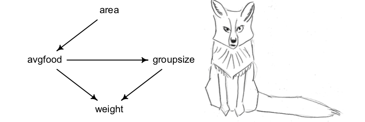

```python
import numpy as np
import polars as pl
import pymc as pm
import arviz as az

# Import (standardized) fox data.
foxes = pl.read_csv('../data/foxes.csv')

# Separate predictors and the outcome.
X = foxes.select(pl.col(['avgfood', 'groupsize'])).to_numpy()
y = foxes.select(pl.col('weight')).to_numpy().flatten()

# Estimate the direct causal effect of avgfood on weight.
with pm.Model() as foxes_model:
  # Data.
  X_data = pm.Data('X_data', X)
  y_data = pm.Data('y_data', y)

  # Priors.
  alpha = pm.Normal('alpha', mu = 0, sigma = 0.2)
  beta = pm.Normal('beta', mu = 0, sigma = 0.5, shape = 2)
  sigma = pm.Exponential('sigma', lam = 1)

  # Likelihood.
  mu = alpha + X_data @ beta
  y_obs = pm.Normal('y_obs', mu = mu, sigma = sigma, observed = y_data)

# Sample.
with foxes_model:
  draws = pm.sample()
```

```python
# Visualize marginal posteriors.
az.plot_forest(draws, var_names=['beta'], combined = True, hdi_prob=0.95)
```

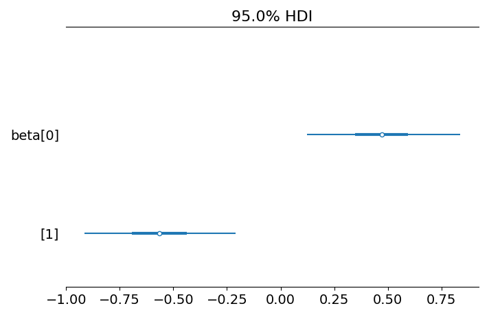

```python
import numpy as np
import polars as pl
import bambi as bmb
import arviz as az

# Import foxes data.
foxes = pl.read_csv('../data/foxes.csv')

# Use Bambi to estimate the direct causal effect of avgfood on weight.
bambi_model_01 = bmb.Model('weight ~ avgfood + groupsize', foxes.to_pandas())
bambi_model_01
```

```
       Formula: weight ~ avgfood + groupsize
        Family: gaussian
          Link: mu = identity
  Observations: 116
        Priors:
    target = mu
        Common-level effects
            Intercept ~ Normal(mu: -0.0, sigma: 2.4892)
            avgfood ~ Normal(mu: 0.0, sigma: 2.5)
            groupsize ~ Normal(mu: 0.0, sigma: 2.5)

        Auxiliary parameters
            sigma ~ HalfStudentT(nu: 4.0, sigma: 0.9957)
```

```python
# Calls pm.sample().
bambi_fit_01 = bambi_model_01.fit()
az.plot_trace(bambi_fit_01, compact = False)
```

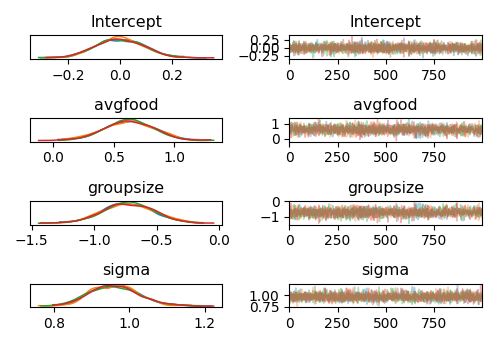

```python
# Visualize marginal posteriors.
az.plot_forest(bambi_fit_01, var_names = ['avgfood', 'groupsize'], combined = True, hdi_prob = 0.95)
```

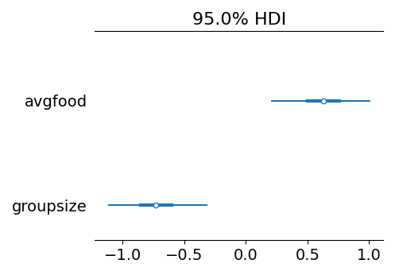

```python
# Use Bambi to estimate the direct causal effect of avgfood on weight by group.
bambi_model_02 = bmb.Model('weight ~ (avgfood|group) + (groupsize|group)', foxes.to_pandas(), noncentered = True)
bambi_model_02
```

```
       Formula: weight ~ (avgfood|group) + (groupsize|group)
        Family: gaussian
          Link: mu = identity
  Observations: 116
        Priors:
    target = mu
        Common-level effects
            Intercept ~ Normal(mu: -0.0, sigma: 2.4892)

        Group-level effects
            1|group ~ Normal(mu: 0.0, sigma: HalfNormal(sigma: 2.4892))
            avgfood|group ~ Normal(mu: 0.0, sigma: HalfNormal(sigma: 2.5))
            groupsize|group ~ Normal(mu: 0.0, sigma: HalfNormal(sigma: 2.5))

        Auxiliary parameters
            sigma ~ HalfStudentT(nu: 4.0, sigma: 0.9957)
```

```python
# Calls pm.sample().
bambi_fit_02 = bambi_model_02.fit()
az.plot_trace(bambi_fit_02, compact = False)
```

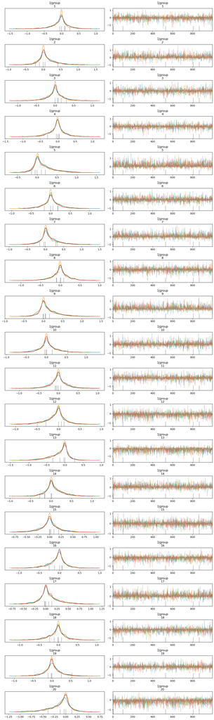

```python
# Visualize marginal posteriors.
az.plot_forest(bambi_fit_02, var_names = ['avgfood|group', 'groupsize|group'], combined = True, hdi_prob = 0.95)
```

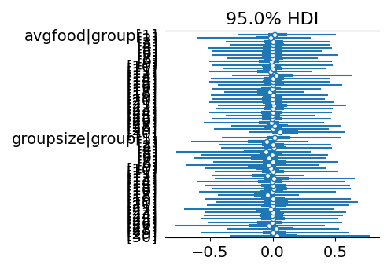